# Case 31: Summary of Data Analysis

IC11-2 | R1, R2, R5, and R6 | Employees Federal Credit Union

Julieta Diaz

IBM 6500, Cal Poly Pomona

November 3, 2026

# Overview

## The Study

- **Client:** Employees Federal Credit Union (EFCU), a credit union for employees of a Fortune 500 firm
- **Problem:** large surplus funds and a low loan-to-share ratio; members are **not borrowing** from the credit union
- **Data:** mail survey of a simple random sample of members, **n = 128** usable responses
- **Approach:** descriptive statistics first to find the story, then inferential tests to confirm it

Table 1: Research questions covered

| RQ | Question |
| --- | --- |
| R1 | Why do people join the credit union? |
| R2 | Why do members borrow from other institutions? |
| R5 | How aware are members of CU services? |
| R6 | How effectively is the CU operated? |

# R1: Why Members Join

## R1: Descriptive Statistics (Q7, Savings Rates)

One reason offered for joining (Q2) is *higher interest rates on savings than other institutions pay*. Q2 is not in the data file, so, following the data analysis table, R1 uses **Q7: the rates the CU pays on share (savings) accounts**.

Table 2: Q7r: Opinion of CU savings rates

| Response | Frequency | Percent |
| --- | --- | --- |
| Very low | 1 | 0.8 |
| Low | 12 | 10.2 |
| Average | 83 | 70.3 |
| High | 22 | 18.6 |
| Very high | 0 | 0.0 |

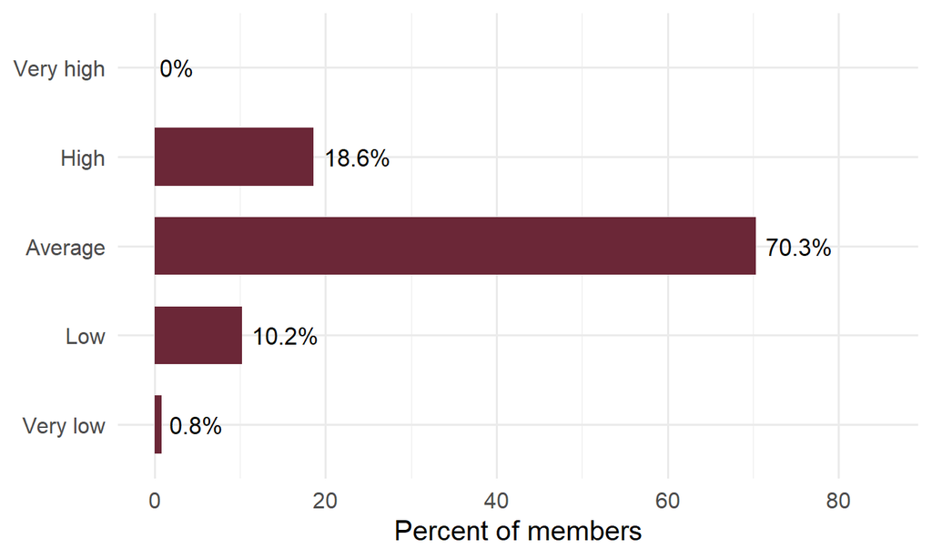

Figure 1: Most members rate the CU’s savings rates as average

## R1: Insight and One-Sample t-Test

Table 3: One-sample t-test of Q7r against the scale midpoint (3 = average)

| Item | n | Mean | SD | Median | Test value | t | df | p |
| --- | --- | --- | --- | --- | --- | --- | --- | --- |
| Q7r: CU savings rates | 118 | 3.07 | 0.57 | 3 | 3 | 1.3 | 117 | 0.196 |

**Insight:** Higher savings rates are **not** a strong reason to join. About **70%** of members call the rates *average* (Table 2), only 19% call them *high*, and the average rating is statistically no different from “average” (*M* = 3.07, *t*(117) = 1.30, *p* = 0.196). The CU should not lead its member recruitment with rate claims; convenience and personal service are likelier selling points.

# R2: Why Members Borrow Elsewhere

## R2: Data Note

**Q28 and Q29 are not in the data file**

The questions that directly answer R2 (Q28, *have you borrowed elsewhere?*, and Q29, *why?*) were not included in the data set. R2 is therefore examined **indirectly**, using the loan-related questions that are available:

- **Q27:** currently have a loan with the CU (yes/no)
- **Q8r:** opinion of the rates the CU charges to borrow (1 = very low to 5 = very high)
- **Q30:** CU loan rates are lower than other institutions (1 = strongly disagree to 5 = strongly agree)
- **Q32, Q34:** loan processing is prompt; applications are simple

## R2: Descriptive Statistics

Table 4: Q27: Currently have a loan with the CU

| Response | Frequency | Percent |
| --- | --- | --- |
| Yes | 58 | 45.3 |
| No | 70 | 54.7 |

Table 5: Q8r: Opinion of CU loan rates

| Response | Frequency | Percent |
| --- | --- | --- |
| Very low | 1 | 0.9 |
| Low | 17 | 15.9 |
| Average | 59 | 55.1 |
| High | 26 | 24.3 |
| Very high | 4 | 3.7 |

Table 6: Loan-related items: descriptive statistics and one-sample t-tests against the midpoint (3)

| Item | n | Mean | SD | t | df | p |
| --- | --- | --- | --- | --- | --- | --- |
| Q8r: CU loan rates (5 = very high) | 107 | 3.14 | 0.76 | 1.91 | 106 | 0.058 |
| Q30: CU loan rates lower than others | 128 | 3.06 | 0.87 | 0.82 | 127 | 0.416 |
| Q32: Loan processing is prompt | 128 | 3.72 | 0.79 | 10.25 | 127 | <.001 |
| Q34: Loan applications are simple | 128 | 3.46 | 0.78 | 6.66 | 127 | <.001 |

## R2: Insight

**Insight:** Members do not see a **rate advantage** in borrowing from the CU, and that is the likeliest reason they borrow elsewhere.

- Fewer than half of members (**45.3%**) currently have a CU loan (Table 4), and the split between borrowers and non-borrowers is not statistically different from 50/50 (χ²(1) = 1.12, *p* = 0.289).
- Members are **neutral** on whether CU loan rates beat other lenders (*M* = 3.06, *p* = 0.416), and more call CU loan rates *high* than *low* (Table 5).
- The loan **process** is not the problem: members agree that processing is prompt (*M* = 3.72, *p* <.001) and applications are simple (*M* = 3.46, *p* <.001).

Recommendation: the CU should review and advertise competitive loan rates. Collecting Q28 and Q29 would confirm the exact reasons.

# R5: Awareness of Services

## R5: Descriptive Statistics

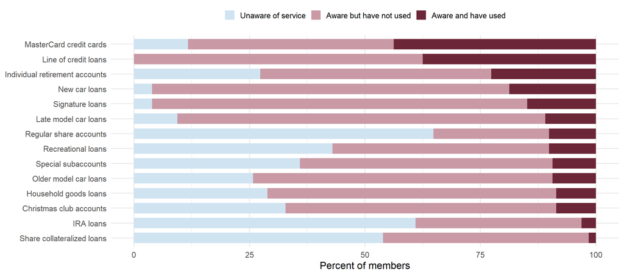

Figure 2: Awareness of CU services (Q13r to Q26r), sorted by percent aware and have used

## R5: Chi-Square Goodness-of-Fit Tests

Table 7: Awareness of each service (%) and chi-square goodness-of-fit test against an equal split (df = 2)

| Service | Unaware (%) | Aware, not used (%) | Aware and used (%) | χ² | p |
| --- | --- | --- | --- | --- | --- |
| Regular share accounts | 64.8 | 25.0 | 10.2 | 61.42 | <.001 |
| Special subaccounts | 35.9 | 54.7 | 9.4 | 39.81 | <.001 |
| Christmas club accounts | 32.8 | 58.6 | 8.6 | 48.02 | <.001 |
| Individual retirement accounts | 27.3 | 50.0 | 22.7 | 16.42 | <.001 |
| MasterCard credit cards | 11.7 | 44.5 | 43.8 | 26.92 | <.001 |
| Signature loans | 3.9 | 81.2 | 14.8 | 134.55 | <.001 |
| New car loans | 3.9 | 77.3 | 18.8 | 115.80 | <.001 |
| Late model car loans | 9.4 | 79.7 | 10.9 | 123.81 | <.001 |
| Older model car loans | 25.8 | 64.8 | 9.4 | 62.36 | <.001 |
| Household goods loans | 28.9 | 62.5 | 8.6 | 56.92 | <.001 |
| Recreational loans | 43.0 | 46.9 | 10.2 | 31.23 | <.001 |
| Share collateralized loans | 53.9 | 44.5 | 1.6 | 59.83 | <.001 |
| IRA loans | 60.9 | 35.9 | 3.1 | 64.56 | <.001 |
| Line of credit loans | 0.0 | 62.5 | 37.5 | 76.00 | <.001 |

## R5: Insight

**Insight:** Members **know about** most loan products but **rarely use them**, and many are unaware of basic savings products.

Recommendation: the problem is converting awareness into use. Targeted loan promotions to members who already know the products could raise the loan-to-share ratio.

# R6: Operational Effectiveness

## R6: Descriptive Statistics and One-Sample t-Tests

Table 8: Operational effectiveness items: descriptive statistics and one-sample t-tests against each scale’s midpoint

| Item | n | Mean | SD | Median | Test value | t | df | p |
| --- | --- | --- | --- | --- | --- | --- | --- | --- |
| Q9r: Statement frequency (3 = about right) | 128 | 2.77 | 0.42 | 3 | 3.0 | -6.10 | 127 | <.001 |
| Q10r: Statement accuracy (1 to 4) | 128 | 3.47 | 0.64 | 4 | 2.5 | 17.15 | 127 | <.001 |
| Q31: Personnel keep information confidential | 128 | 3.95 | 0.68 | 4 | 3.0 | 15.74 | 127 | <.001 |
| Q32: Prompt in processing loans | 128 | 3.72 | 0.79 | 4 | 3.0 | 10.25 | 127 | <.001 |
| Q33: Services meet members’ needs | 128 | 3.59 | 0.68 | 4 | 3.0 | 9.87 | 127 | <.001 |
| Q34: Loan applications simple | 128 | 3.46 | 0.78 | 4 | 3.0 | 6.66 | 127 | <.001 |
| Q37r: Overall management (5 = excellent) | 121 | 4.07 | 0.73 | 4 | 3.0 | 16.12 | 120 | <.001 |

## R6: Statements and Overall Rating

Table 9: Yes/no items and chi-square goodness-of-fit tests (df = 1)

| Item | n | Yes (%) | No (%) | χ² | p |
| --- | --- | --- | --- | --- | --- |
| Q11: Statements easy to understand | 128 | 97.7 | 2.3 | 116.28 | <.001 |
| Q12: CU keeps account information confidential | 106 | 69.8 | 30.2 | 16.64 | <.001 |

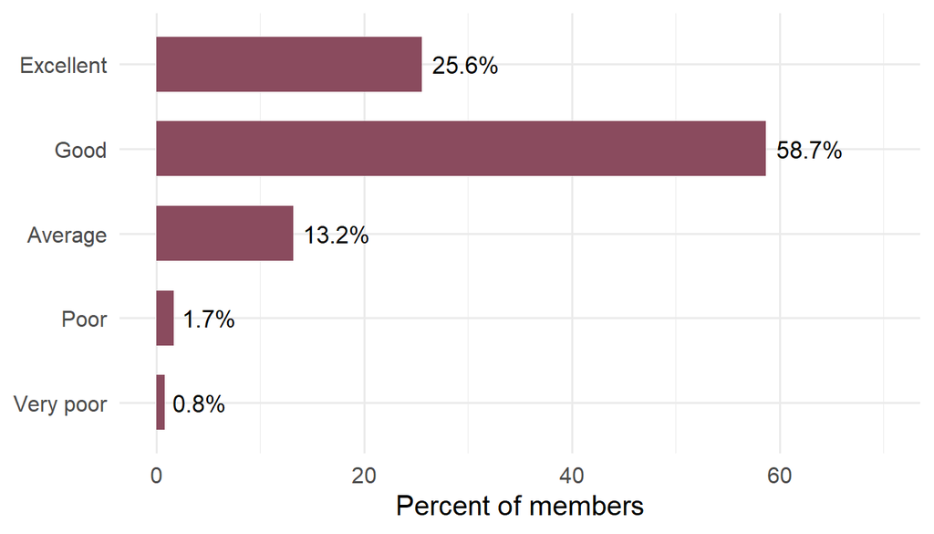

Figure 3: Q37r: How well the CU is managed and operated

## R6: Insight

**Insight:** Members believe the credit union is **well run**, with one area to watch: **privacy**.

- **84%** rate overall management as good or excellent (Figure 3), well above “average” (*M* = 4.07, *t*(120) = 16.12, *p* <.001).
- Statements are accurate (95% good or excellent) and easy to understand (97.7% yes). Most say statement frequency is about right (77%), but 23% want statements **more often** (*p* <.001).
- Members agree the CU is prompt, meets their needs, and keeps information confidential (all *p* < .001, Table 8), yet **30.2%** answered *no* when asked whether account information is kept confidential (Table 9).

Recommendation: keep current service standards, offer more frequent statements, and communicate privacy safeguards to members.

# Summary

## Summary of Insights

Table 10: Summary of findings

| RQ | Key finding | Implication for EFCU |
| --- | --- | --- |
| R1 | Savings rates are seen as **average**, not a reason to join | Lead with convenience and service, not rates |
| R2 | Members see **no loan-rate advantage**; the loan process itself is rated well | Review and promote competitive loan rates |
| R5 | Members **know** most loan products but **rarely use** them | Convert awareness into use with targeted loan offers |
| R6 | The CU is seen as **well run**; some doubt about **confidentiality** | Maintain service; communicate privacy and offer more frequent statements |

## Appendix: Links

- [This presentation on GitHub Pages](https://jukedz.github.io/ibm6500-assignments/IC11-2-Case31-Summary-R1-R2-R5-R6/julieta-diaz-case31-summary.html)
- [Source folder on GitHub](https://github.com/jukedz/ibm6500-assignments/tree/main/IC11-2-Case31-Summary-R1-R2-R5-R6)